# Risk Factor Analysis

## Outcome Variable

**Outcome Variable:** wast_rec90d

## Predictor Variables

**Intervention Variable:** fhtcm

**Adjustment Set:**

- arm
- W_mage
- W_fage
- meducyrs
- feducyrs
- W_mhtcm
- W_mwtkg
- W_mbmi
- single
- delta_W_mage
- delta_W_fage
- delta_meducyrs
- delta_feducyrs
- delta_W_mhtcm
- delta_W_mwtkg
- delta_W_mbmi
- delta_single

## Stratifying Variables

The analysis was stratified on these variable(s):

- agecat
- studyid
- country

## Data Summary

| agecat | studyid | country | fhtcm | wast_rec90d | n_cell | n |
| --- | --- | --- | --- | --- | --- | --- |
| 0-24 months | ki1000304b-SAS-CompFeed | INDIA | >=167 cm | 0 | 117 | 463 |
| 0-24 months | ki1000304b-SAS-CompFeed | INDIA | >=167 cm | 1 | 84 | 463 |
| 0-24 months | ki1000304b-SAS-CompFeed | INDIA | <162 cm | 0 | 68 | 463 |
| 0-24 months | ki1000304b-SAS-CompFeed | INDIA | <162 cm | 1 | 42 | 463 |
| 0-24 months | ki1000304b-SAS-CompFeed | INDIA | [162-167) cm | 0 | 96 | 463 |
| 0-24 months | ki1000304b-SAS-CompFeed | INDIA | [162-167) cm | 1 | 56 | 463 |
| 0-24 months | ki1000304b-SAS-FoodSuppl | INDIA | >=167 cm | 0 | 61 | 223 |
| 0-24 months | ki1000304b-SAS-FoodSuppl | INDIA | >=167 cm | 1 | 3 | 223 |
| 0-24 months | ki1000304b-SAS-FoodSuppl | INDIA | <162 cm | 0 | 97 | 223 |
| 0-24 months | ki1000304b-SAS-FoodSuppl | INDIA | <162 cm | 1 | 5 | 223 |
| 0-24 months | ki1000304b-SAS-FoodSuppl | INDIA | [162-167) cm | 0 | 52 | 223 |
| 0-24 months | ki1000304b-SAS-FoodSuppl | INDIA | [162-167) cm | 1 | 5 | 223 |
| 0-24 months | ki1101329-Keneba | GAMBIA | >=167 cm | 0 | 324 | 1086 |
| 0-24 months | ki1101329-Keneba | GAMBIA | >=167 cm | 1 | 380 | 1086 |
| 0-24 months | ki1101329-Keneba | GAMBIA | <162 cm | 0 | 39 | 1086 |
| 0-24 months | ki1101329-Keneba | GAMBIA | <162 cm | 1 | 41 | 1086 |
| 0-24 months | ki1101329-Keneba | GAMBIA | [162-167) cm | 0 | 129 | 1086 |
| 0-24 months | ki1101329-Keneba | GAMBIA | [162-167) cm | 1 | 173 | 1086 |
| 0-24 months | ki1119695-PROBIT | BELARUS | >=167 cm | 0 | 418 | 3583 |
| 0-24 months | ki1119695-PROBIT | BELARUS | >=167 cm | 1 | 2931 | 3583 |
| 0-24 months | ki1119695-PROBIT | BELARUS | <162 cm | 0 | 9 | 3583 |
| 0-24 months | ki1119695-PROBIT | BELARUS | <162 cm | 1 | 40 | 3583 |
| 0-24 months | ki1119695-PROBIT | BELARUS | [162-167) cm | 0 | 14 | 3583 |
| 0-24 months | ki1119695-PROBIT | BELARUS | [162-167) cm | 1 | 171 | 3583 |
| 0-24 months | ki1135781-COHORTS | GUATEMALA | >=167 cm | 0 | 8 | 128 |
| 0-24 months | ki1135781-COHORTS | GUATEMALA | >=167 cm | 1 | 4 | 128 |
| 0-24 months | ki1135781-COHORTS | GUATEMALA | <162 cm | 0 | 62 | 128 |
| 0-24 months | ki1135781-COHORTS | GUATEMALA | <162 cm | 1 | 16 | 128 |
| 0-24 months | ki1135781-COHORTS | GUATEMALA | [162-167) cm | 0 | 30 | 128 |
| 0-24 months | ki1135781-COHORTS | GUATEMALA | [162-167) cm | 1 | 8 | 128 |

[output cut: 60 more lines]

The following strata were considered:

- agecat: 0-24 months, studyid: ki1000304b-SAS-CompFeed, country: INDIA
- agecat: 0-24 months, studyid: ki1000304b-SAS-FoodSuppl, country: INDIA
- agecat: 0-24 months, studyid: ki1101329-Keneba, country: GAMBIA
- agecat: 0-24 months, studyid: ki1119695-PROBIT, country: BELARUS
- agecat: 0-24 months, studyid: ki1135781-COHORTS, country: GUATEMALA
- agecat: 0-6 months, studyid: ki1000304b-SAS-CompFeed, country: INDIA
- agecat: 0-6 months, studyid: ki1000304b-SAS-FoodSuppl, country: INDIA
- agecat: 0-6 months, studyid: ki1101329-Keneba, country: GAMBIA
- agecat: 0-6 months, studyid: ki1119695-PROBIT, country: BELARUS
- agecat: 0-6 months, studyid: ki1135781-COHORTS, country: GUATEMALA
- agecat: 6-24 months, studyid: ki1000304b-SAS-CompFeed, country: INDIA
- agecat: 6-24 months, studyid: ki1000304b-SAS-FoodSuppl, country: INDIA
- agecat: 6-24 months, studyid: ki1101329-Keneba, country: GAMBIA
- agecat: 6-24 months, studyid: ki1119695-PROBIT, country: BELARUS
- agecat: 6-24 months, studyid: ki1135781-COHORTS, country: GUATEMALA

### Dropped Strata

Some strata were dropped due to rare outcomes:

- agecat: 0-24 months, studyid: ki1000304b-SAS-FoodSuppl, country: INDIA
- agecat: 0-24 months, studyid: ki1135781-COHORTS, country: GUATEMALA
- agecat: 0-6 months, studyid: ki1000304b-SAS-FoodSuppl, country: INDIA
- agecat: 0-6 months, studyid: ki1135781-COHORTS, country: GUATEMALA
- agecat: 6-24 months, studyid: ki1000304b-SAS-FoodSuppl, country: INDIA
- agecat: 6-24 months, studyid: ki1119695-PROBIT, country: BELARUS
- agecat: 6-24 months, studyid: ki1135781-COHORTS, country: GUATEMALA

## Methods Detail

We’re interested in the causal parameters $E[Y_a]$ for all values of $a \in \mathcal{A}$. These parameters represent the mean outcome if, possibly contrary to fact, we intervened to set all units to have $A=a$. Under the randomization and positivity assumptions, these are identified by the statistical parameters $\psi_a=E_W[E_{Y|A,W}(Y|A=a,W)]$. In addition, we’re interested in the mean of $Y$, $E[Y]$ under no intervention (the observed mean). We will estimate these parameters by using SuperLearner to fit the relevant likelihood factors – $E_{Y|A,W}(Y|A=a,W)$ and $p(A=a|W)$, and then updating our likelihood fit using a joint TMLE.

For unadjusted analyses ($W=\{\}$), initial likelihoods were estimated using Lrnr_glm to estimate the simple $E(Y|A)$ and Lrnr_mean to estimate $p(A)$. For adjusted analyses, a small library containing Lrnr_glmnet, Lrnr_xgboost, and Lrnr_mean was used.

Having estimated these parameters, we will then use the delta method to estimate relative risks and attributable risks relative to a prespecified baseline level of $A$.

# Results Detail

## Results Plots

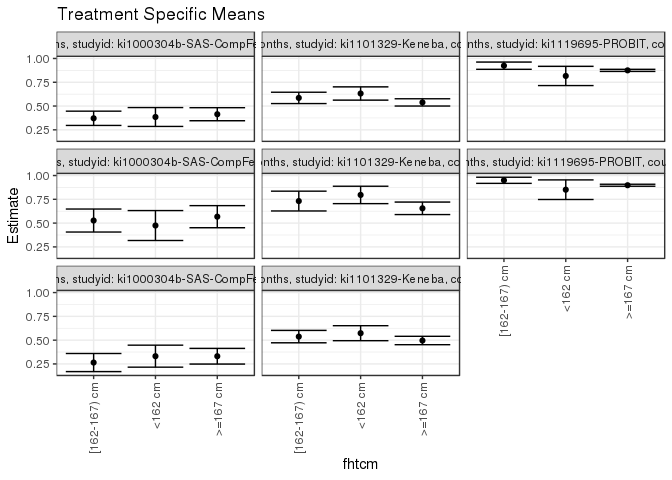

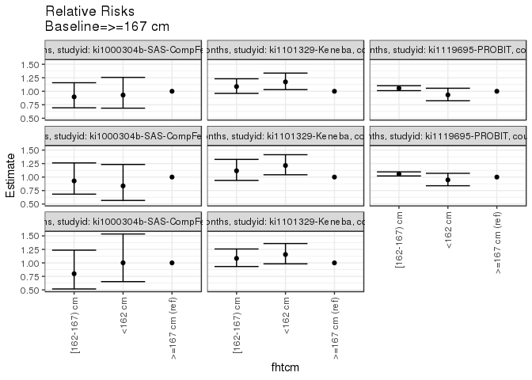

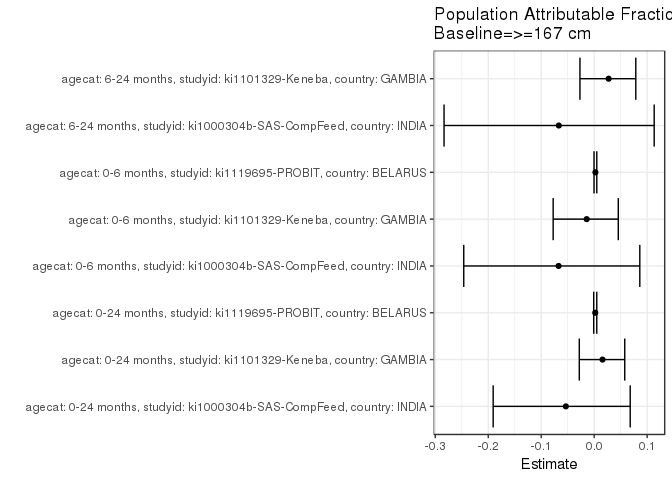

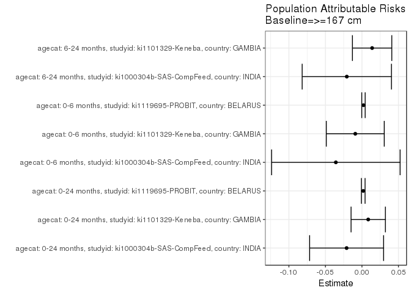

## Results Table

### Parameter: TSM

| agecat | studyid | country | intervention_level | baseline_level | estimate | ci_lower | ci_upper |
| --- | --- | --- | --- | --- | --- | --- | --- |
| 0-24 months | ki1000304b-SAS-CompFeed | INDIA | >=167 cm | NA | 0.4141018 | 0.3457267 | 0.4824769 |
| 0-24 months | ki1000304b-SAS-CompFeed | INDIA | <162 cm | NA | 0.3848740 | 0.2855957 | 0.4841523 |
| 0-24 months | ki1000304b-SAS-CompFeed | INDIA | [162-167) cm | NA | 0.3712554 | 0.2961790 | 0.4463319 |
| 0-24 months | ki1101329-Keneba | GAMBIA | >=167 cm | NA | 0.5383648 | 0.5001130 | 0.5766167 |
| 0-24 months | ki1101329-Keneba | GAMBIA | <162 cm | NA | 0.6319120 | 0.5622640 | 0.7015600 |
| 0-24 months | ki1101329-Keneba | GAMBIA | [162-167) cm | NA | 0.5857168 | 0.5259921 | 0.6454414 |
| 0-24 months | ki1119695-PROBIT | BELARUS | >=167 cm | NA | 0.8751866 | 0.8640642 | 0.8863090 |
| 0-24 months | ki1119695-PROBIT | BELARUS | <162 cm | NA | 0.8163265 | 0.7153722 | 0.9172808 |
| 0-24 months | ki1119695-PROBIT | BELARUS | [162-167) cm | NA | 0.9243243 | 0.8863804 | 0.9622683 |
| 0-6 months | ki1000304b-SAS-CompFeed | INDIA | >=167 cm | NA | 0.5675419 | 0.4512724 | 0.6838114 |
| 0-6 months | ki1000304b-SAS-CompFeed | INDIA | <162 cm | NA | 0.4746409 | 0.3173348 | 0.6319471 |
| 0-6 months | ki1000304b-SAS-CompFeed | INDIA | [162-167) cm | NA | 0.5271916 | 0.4063473 | 0.6480359 |
| 0-6 months | ki1101329-Keneba | GAMBIA | >=167 cm | NA | 0.6553864 | 0.5896784 | 0.7210944 |
| 0-6 months | ki1101329-Keneba | GAMBIA | <162 cm | NA | 0.7959717 | 0.7044870 | 0.8874564 |
| 0-6 months | ki1101329-Keneba | GAMBIA | [162-167) cm | NA | 0.7315845 | 0.6277464 | 0.8354226 |
| 0-6 months | ki1119695-PROBIT | BELARUS | >=167 cm | NA | 0.8979845 | 0.8874533 | 0.9085156 |
| 0-6 months | ki1119695-PROBIT | BELARUS | <162 cm | NA | 0.8510638 | 0.7480411 | 0.9540866 |
| 0-6 months | ki1119695-PROBIT | BELARUS | [162-167) cm | NA | 0.9500000 | 0.9177878 | 0.9822122 |
| 6-24 months | ki1000304b-SAS-CompFeed | INDIA | >=167 cm | NA | 0.3310822 | 0.2487661 | 0.4133982 |
| 6-24 months | ki1000304b-SAS-CompFeed | INDIA | <162 cm | NA | 0.3314807 | 0.2158559 | 0.4471055 |
| 6-24 months | ki1000304b-SAS-CompFeed | INDIA | [162-167) cm | NA | 0.2645879 | 0.1694965 | 0.3596793 |
| 6-24 months | ki1101329-Keneba | GAMBIA | >=167 cm | NA | 0.4961968 | 0.4520768 | 0.5403168 |
| 6-24 months | ki1101329-Keneba | GAMBIA | <162 cm | NA | 0.5731925 | 0.4944283 | 0.6519568 |
| 6-24 months | ki1101329-Keneba | GAMBIA | [162-167) cm | NA | 0.5373238 | 0.4721879 | 0.6024597 |

### Parameter: E(Y)

| agecat | studyid | country | intervention_level | baseline_level | estimate | ci_lower | ci_upper |
| --- | --- | --- | --- | --- | --- | --- | --- |
| 0-24 months | ki1000304b-SAS-CompFeed | INDIA | NA | NA | 0.3930886 | 0.3463071 | 0.4398700 |
| 0-24 months | ki1101329-Keneba | GAMBIA | NA | NA | 0.5469613 | 0.5145713 | 0.5793513 |
| 0-24 months | ki1119695-PROBIT | BELARUS | NA | NA | 0.8769188 | 0.8662437 | 0.8875939 |
| 0-6 months | ki1000304b-SAS-CompFeed | INDIA | NA | NA | 0.5317919 | 0.4572362 | 0.6063476 |
| 0-6 months | ki1101329-Keneba | GAMBIA | NA | NA | 0.6462585 | 0.5919377 | 0.7005793 |
| 0-6 months | ki1119695-PROBIT | BELARUS | NA | NA | 0.9000579 | 0.8899697 | 0.9101462 |
| 6-24 months | ki1000304b-SAS-CompFeed | INDIA | NA | NA | 0.3103448 | 0.2551537 | 0.3655360 |
| 6-24 months | ki1101329-Keneba | GAMBIA | NA | NA | 0.5101010 | 0.4728139 | 0.5473881 |

### Parameter: RR

| agecat | studyid | country | intervention_level | baseline_level | estimate | ci_lower | ci_upper |
| --- | --- | --- | --- | --- | --- | --- | --- |
| 0-24 months | ki1000304b-SAS-CompFeed | INDIA | >=167 cm | >=167 cm | 1.0000000 | 1.0000000 | 1.000000 |
| 0-24 months | ki1000304b-SAS-CompFeed | INDIA | <162 cm | >=167 cm | 0.9294187 | 0.6871878 | 1.257035 |
| 0-24 months | ki1000304b-SAS-CompFeed | INDIA | [162-167) cm | >=167 cm | 0.8965318 | 0.6940916 | 1.158016 |
| 0-24 months | ki1101329-Keneba | GAMBIA | >=167 cm | >=167 cm | 1.0000000 | 1.0000000 | 1.000000 |
| 0-24 months | ki1101329-Keneba | GAMBIA | <162 cm | >=167 cm | 1.1737616 | 1.0306659 | 1.336724 |
| 0-24 months | ki1101329-Keneba | GAMBIA | [162-167) cm | >=167 cm | 1.0879551 | 0.9612928 | 1.231307 |
| 0-24 months | ki1119695-PROBIT | BELARUS | >=167 cm | >=167 cm | 1.0000000 | 1.0000000 | 1.000000 |
| 0-24 months | ki1119695-PROBIT | BELARUS | <162 cm | >=167 cm | 0.9327457 | 0.8237043 | 1.056222 |
| 0-24 months | ki1119695-PROBIT | BELARUS | [162-167) cm | >=167 cm | 1.0561454 | 1.0117213 | 1.102520 |
| 0-6 months | ki1000304b-SAS-CompFeed | INDIA | >=167 cm | >=167 cm | 1.0000000 | 1.0000000 | 1.000000 |
| 0-6 months | ki1000304b-SAS-CompFeed | INDIA | <162 cm | >=167 cm | 0.8363100 | 0.5668086 | 1.233952 |
| 0-6 months | ki1000304b-SAS-CompFeed | INDIA | [162-167) cm | >=167 cm | 0.9289035 | 0.6836158 | 1.262203 |
| 0-6 months | ki1101329-Keneba | GAMBIA | >=167 cm | >=167 cm | 1.0000000 | 1.0000000 | 1.000000 |
| 0-6 months | ki1101329-Keneba | GAMBIA | <162 cm | >=167 cm | 1.2145075 | 1.0429385 | 1.414300 |
| 0-6 months | ki1101329-Keneba | GAMBIA | [162-167) cm | >=167 cm | 1.1162644 | 0.9385034 | 1.327695 |
| 0-6 months | ki1119695-PROBIT | BELARUS | >=167 cm | >=167 cm | 1.0000000 | 1.0000000 | 1.000000 |
| 0-6 months | ki1119695-PROBIT | BELARUS | <162 cm | >=167 cm | 0.9477489 | 0.8392185 | 1.070315 |
| 0-6 months | ki1119695-PROBIT | BELARUS | [162-167) cm | >=167 cm | 1.0579247 | 1.0206409 | 1.096570 |
| 6-24 months | ki1000304b-SAS-CompFeed | INDIA | >=167 cm | >=167 cm | 1.0000000 | 1.0000000 | 1.000000 |
| 6-24 months | ki1000304b-SAS-CompFeed | INDIA | <162 cm | >=167 cm | 1.0012037 | 0.6528165 | 1.535514 |
| 6-24 months | ki1000304b-SAS-CompFeed | INDIA | [162-167) cm | >=167 cm | 0.7991608 | 0.5169126 | 1.235524 |
| 6-24 months | ki1101329-Keneba | GAMBIA | >=167 cm | >=167 cm | 1.0000000 | 1.0000000 | 1.000000 |
| 6-24 months | ki1101329-Keneba | GAMBIA | <162 cm | >=167 cm | 1.1551718 | 0.9823012 | 1.358465 |
| 6-24 months | ki1101329-Keneba | GAMBIA | [162-167) cm | >=167 cm | 1.0828845 | 0.9325168 | 1.257499 |

### Parameter: PAR

| agecat | studyid | country | intervention_level | baseline_level | estimate | ci_lower | ci_upper |
| --- | --- | --- | --- | --- | --- | --- | --- |
| 0-24 months | ki1000304b-SAS-CompFeed | INDIA | >=167 cm | NA | -0.0210133 | -0.0716370 | 0.0296105 |
| 0-24 months | ki1101329-Keneba | GAMBIA | >=167 cm | NA | 0.0085965 | -0.0149019 | 0.0320949 |
| 0-24 months | ki1119695-PROBIT | BELARUS | >=167 cm | NA | 0.0017322 | -0.0008017 | 0.0042660 |
| 0-6 months | ki1000304b-SAS-CompFeed | INDIA | >=167 cm | NA | -0.0357500 | -0.1237271 | 0.0522271 |
| 0-6 months | ki1101329-Keneba | GAMBIA | >=167 cm | NA | -0.0091279 | -0.0487942 | 0.0305384 |
| 0-6 months | ki1119695-PROBIT | BELARUS | >=167 cm | NA | 0.0020734 | -0.0002613 | 0.0044081 |
| 6-24 months | ki1000304b-SAS-CompFeed | INDIA | >=167 cm | NA | -0.0207373 | -0.0818437 | 0.0403690 |
| 6-24 months | ki1101329-Keneba | GAMBIA | >=167 cm | NA | 0.0139042 | -0.0130408 | 0.0408493 |

### Parameter: PAF

| agecat | studyid | country | intervention_level | baseline_level | estimate | ci_lower | ci_upper |
| --- | --- | --- | --- | --- | --- | --- | --- |
| 0-24 months | ki1000304b-SAS-CompFeed | INDIA | >=167 cm | NA | -0.0534569 | -0.1907371 | 0.0679963 |
| 0-24 months | ki1101329-Keneba | GAMBIA | >=167 cm | NA | 0.0157168 | -0.0281186 | 0.0576832 |
| 0-24 months | ki1119695-PROBIT | BELARUS | >=167 cm | NA | 0.0019753 | -0.0009199 | 0.0048621 |
| 0-6 months | ki1000304b-SAS-CompFeed | INDIA | >=167 cm | NA | -0.0672255 | -0.2463010 | 0.0861194 |
| 0-6 months | ki1101329-Keneba | GAMBIA | >=167 cm | NA | -0.0141242 | -0.0774707 | 0.0454980 |
| 0-6 months | ki1119695-PROBIT | BELARUS | >=167 cm | NA | 0.0023037 | -0.0002958 | 0.0048964 |
| 6-24 months | ki1000304b-SAS-CompFeed | INDIA | >=167 cm | NA | -0.0668203 | -0.2834998 | 0.1132795 |
| 6-24 months | ki1101329-Keneba | GAMBIA | >=167 cm | NA | 0.0272578 | -0.0268875 | 0.0785481 |